# SS3859 Final Project

Tyler Lin

12/08/2023

# **Introduction**

### Motivation

A general manager for the NBA has such a difficult job. They have to compete against other GM’s to construct a team good enough to win everything. The obvious answer would be to sign the best players in the world, however that’s just not a viable solution due to budgets, salary caps, luxury tax, etc. So what is a good way to determine the value of a player? How do we make sure we don’t overpay to optimize our roster building?

I will attempt to determine a players value from a pure statistical perspective. After my analysis, I should be able to predict a players salary given their stat line. With this prediction, I also would be able to determine which players are over/underrated compared to how much they get paid.

### Data Introduction

All data was retrieve from: [NBA Player Salaries](https://www.kaggle.com/datasets/jamiewelsh2/nba-player-salaries-2022-23-season?select=nba_2022-23_all_stats_with_salary.csv)

Notable Variables:

Response Variable: Salary (This is the value we want to predict by the end)

Excluded Variables: These variables I have chosen to leave out for simplicity:

- Player Name
- Teams

Some variables have an overlap with others. Below I have provided a description of all the variables, and why I have/haven’t included them in my analysis. [Full List Of Variables](https://docs.google.com/document/d/178A2UeYJJhzocjRaNXQU9IXSAzRg-9vEtHH62ep-XTI/edit?usp=sharing)

### Data Visualization

```r
# Libraries
library(readxl)

# Extract Data
full <- read.csv("nba_2022-23_all_stats_with_salary.csv", check.names = FALSE)
include <- read_excel("NBA Stats Variable Decisions.xlsx")

# Clean Up Data
include <- include[which(include$Decision == "Included"),]$Variable
data <- subset(full, select = include)
data$Position <- ifelse(grepl("-", data$Position), "M", data$Position)
data <- na.omit(data)

# Summarize continuous variables
noCat = data[,!(names(data) %in% c("Position"))]
summary(noCat)
```

```
##      Salary              Age              GP             GS
##  Min.   :    5849   Min.   :19.00   Min.   : 1.0   Min.   : 0.00
##  1st Qu.: 1910860   1st Qu.:23.00   1st Qu.:35.0   1st Qu.: 1.00
##  Median : 4124280   Median :25.00   Median :56.0   Median : 9.00
##  Mean   : 8939026   Mean   :25.92   Mean   :50.8   Mean   :23.95
##  3rd Qu.:11215260   3rd Qu.:29.00   3rd Qu.:69.0   3rd Qu.:50.00
##  Max.   :48070014   Max.   :42.00   Max.   :83.0   Max.   :83.00
##        MP             3P%              2P%              eFG%
##  Min.   : 2.80   Min.   :0.0000   Min.   :0.0000   Min.   :0.1840
##  1st Qu.:13.40   1st Qu.:0.2970   1st Qu.:0.4920   1st Qu.:0.4980
##  Median :19.60   Median :0.3460   Median :0.5370   Median :0.5380
##  Mean   :20.76   Mean   :0.3273   Mean   :0.5366   Mean   :0.5366
##  3rd Qu.:28.60   3rd Qu.:0.3870   3rd Qu.:0.5890   3rd Qu.:0.5750
##  Max.   :37.40   Max.   :1.0000   Max.   :1.0000   Max.   :0.8570
##       FT%              TRB              AST              STL
##  Min.   :0.0000   Min.   : 0.000   Min.   : 0.000   Min.   :0.0000
##  1st Qu.:0.6970   1st Qu.: 2.100   1st Qu.: 0.900   1st Qu.:0.3000
##  Median :0.7690   Median : 3.200   Median : 1.400   Median :0.6000
##  Mean   :0.7596   Mean   : 3.646   Mean   : 2.215   Mean   :0.6316
##  3rd Qu.:0.8440   3rd Qu.: 4.500   3rd Qu.: 3.000   3rd Qu.:0.8000
##  Max.   :1.0000   Max.   :12.500   Max.   :10.700   Max.   :2.2000
##       BLK              TOV              PF             PTS
##  Min.   :0.0000   Min.   :0.000   Min.   :0.000   Min.   : 0.900
##  1st Qu.:0.2000   1st Qu.:0.600   1st Qu.:1.300   1st Qu.: 4.700
##  Median :0.3000   Median :0.900   Median :1.700   Median : 7.700
##  Mean   :0.3891   Mean   :1.166   Mean   :1.765   Mean   : 9.638
##  3rd Qu.:0.5000   3rd Qu.:1.500   3rd Qu.:2.200   3rd Qu.:12.500
##  Max.   :2.5000   Max.   :4.100   Max.   :5.000   Max.   :33.100
##       PER             TS%              USG%            OWS
##  Min.   :-1.40   Min.   :0.2260   Min.   : 7.40   Min.   :-1.900
##  1st Qu.:10.30   1st Qu.:0.5280   1st Qu.:14.40   1st Qu.: 0.100
##  Median :13.00   Median :0.5680   Median :17.70   Median : 0.700
##  Mean   :13.42   Mean   :0.5668   Mean   :18.43   Mean   : 1.267
##  3rd Qu.:16.20   3rd Qu.:0.6070   3rd Qu.:21.10   3rd Qu.: 1.900
##  Max.   :31.40   Max.   :0.8250   Max.   :38.80   Max.   : 9.600
##       DWS              WS             WS/48               OBPM
##  Min.   :0.000   Min.   :-1.600   Min.   :-0.21800   Min.   :-11.300
##  1st Qu.:0.300   1st Qu.: 0.400   1st Qu.: 0.05100   1st Qu.: -2.800
##  Median :0.900   Median : 1.800   Median : 0.08700   Median : -1.300
##  Mean   :1.183   Mean   : 2.449   Mean   : 0.08598   Mean   : -1.144
##  3rd Qu.:1.900   3rd Qu.: 3.700   3rd Qu.: 0.12800   3rd Qu.:  0.400
##  Max.   :4.800   Max.   :12.600   Max.   : 0.27700   Max.   :  8.300
##       DBPM               BPM              VORP
##  Min.   :-4.70000   Min.   :-15.00   Min.   :-1.3000
##  1st Qu.:-0.90000   1st Qu.: -3.20   1st Qu.:-0.1000
##  Median :-0.10000   Median : -1.20   Median : 0.1000
##  Mean   :-0.09446   Mean   : -1.24   Mean   : 0.5702
##  3rd Qu.: 0.70000   3rd Qu.:  0.60   3rd Qu.: 0.9000
##  Max.   : 4.00000   Max.   :  9.20   Max.   : 6.4000
```

[Graphs of all the variables](https://drive.google.com/file/d/1td4PX_DyyQfypFztv3a7dFHQLoahbgjm/view?usp=drive_link)

# **Regression Model Creation**

### **Win Shares**

As stated in my variable description, all of the win shares variables feel significant. But they also seem very related. So, to be proactive in preventing multicollinearity I will test them against each other.

```r
# Libraries
library(faraway)
# Create Model and summary to test theory
lm_WS <- lm(formula = Salary ~ ., data = data[,c(1, 21:24)])
summary(lm_WS)
```

```
##
## Call:
## lm(formula = Salary ~ ., data = data[, c(1, 21:24)])
##
## Residuals:
##       Min        1Q    Median        3Q       Max
## -18275115  -4189904  -1544538   1702265  43379546
##
## Coefficients:
##              Estimate Std. Error t value Pr(>|t|)
## (Intercept)   3098456     806785   3.840 0.000141 ***
## OWS           6356095    8954174   0.710 0.478185
## DWS           6972675    8942942   0.780 0.436007
## WS           -3564941    8939217  -0.399 0.690241
## `WS/48`     -20059718    8999691  -2.229 0.026337 *
## ---
## Signif. codes:  0 '***' 0.001 '**' 0.01 '*' 0.05 '.' 0.1 ' ' 1
##
## Residual standard error: 8566000 on 428 degrees of freedom
## Multiple R-squared:  0.3898, Adjusted R-squared:  0.3841
## F-statistic: 68.36 on 4 and 428 DF,  p-value: < 2.2e-16
```

### **Box Plus Minutes**

Similar to win shares, all of the BPM variables seem significant, but highly related. So, using VIF I will test to see if there is any collinearity.

```r
lm_BPM <- lm(formula = Salary ~ ., data = data[,c(1, 25:27)])
vif(lm_BPM)
```

```
##      OBPM      DBPM       BPM
## 2551.8161  544.9818 3490.5252
```

These VIF’s are extremely large, thus these variables are highly related. So once again for simplicity, I will take the all around variable BPM over the offensive/defensive BPM.

```r
# First model reduction
data <- data[, !names(data) %in% c("OWS", "DWS", "WS", "OBPM", "DBPM")]
```

### **Check Assumptions**

Before reducing the model further, lets check all of the assumptions needed for a linear regression model.

```r
# Libraries
library(lmtest)
```

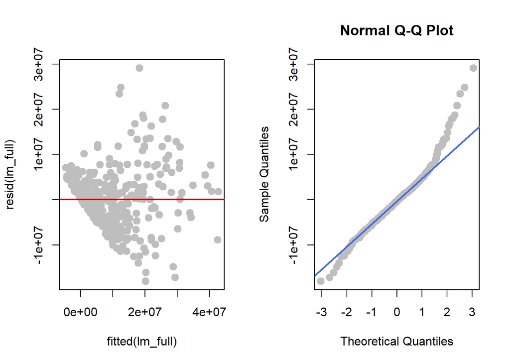

```r
lm_full <- lm(Salary ~ . , data = data)

par(mfrow=c(1,2))
plot(fitted(lm_full), resid(lm_full), col = "grey", pch = 20, cex = 2)
abline(h=0, col = "red3", lwd = 2)

qqnorm(resid(lm_full), col = "grey", pch = 20, cex = 2)
qqline(resid(lm_full), col = "royalblue", lwd = 2 )
```

```r
bptest(lm_full)
```

```
##
##  studentized Breusch-Pagan test
##
## data:  lm_full
## BP = 91.191, df = 26, p-value = 3.575e-09
```

```r
shapiro.test(resid(lm_full))
```

```
##
##  Shapiro-Wilk normality test
##
## data:  resid(lm_full)
## W = 0.96049, p-value = 2.184e-09
```

- Residual plot has roughly and equal amount of points above/below 0. Thus we can assume the linearity assumption is not violated.
- Both the SW test and the QQ plot suggest the normality assumption is violated.
- The BP test and the residual plots suggest the equal variance assumption is violated.

To fix the model I will try box cox transformations.

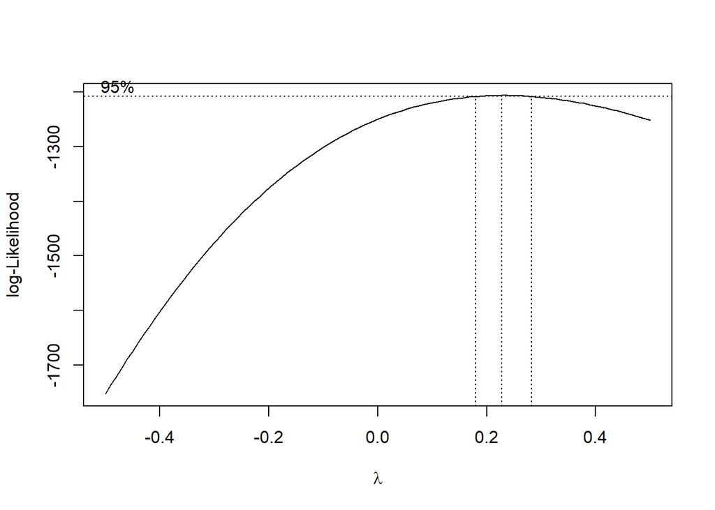

```r
library(MASS)

boxcox(lm_full, lambda = seq(-0.5,0.5, by = 0.1))
```

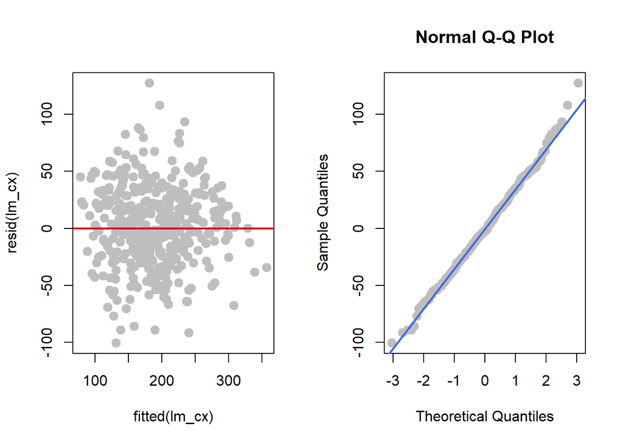

```r
lambda <- 0.25

lm_cx <- lm(((Salary^(lambda)-1)/(lambda)) ~ ., data = data)


par(mfrow=c(1,2))
plot(fitted(lm_cx), resid(lm_cx), col = "grey", pch = 20, cex = 2)
abline(h=0, col = "red3", lwd = 2)

qqnorm(resid(lm_cx), col = "grey", pch = 20, cex = 2)
qqline(resid(lm_cx), col = "royalblue", lwd = 2 )
```

```r
bptest(lm_cx)
```

```
##
##  studentized Breusch-Pagan test
##
## data:  lm_cx
## BP = 83.109, df = 26, p-value = 6.899e-08
```

```r
shapiro.test(resid(lm_cx))
```

```
##
##  Shapiro-Wilk normality test
##
## data:  resid(lm_cx)
## W = 0.99703, p-value = 0.6233
```

Note: The graph suggest that the equal variance assumption is still violated. But for the purpose of this assignment, this model is sufficient (Approved by Professor).

### **Reducing The Model**

Due to how many variables I have to consider I choose to use BIC. This way I can punish complex models more.

```r
n <- nrow(data)
lm_cx_bic <- step(lm_full, direction = "both", k = log(n), trace = FALSE)
```

# **Analysis**

Now that our model is completed we can do some analysis and predictions on current players.

### **Significant Predictors**

```r
summary(lm_cx_bic)
```

```
##
## Call:
## lm(formula = Salary ~ Age + `3P%` + PTS + VORP + `WS/48`, data = data)
##
## Residuals:
##       Min        1Q    Median        3Q       Max
## -18355722  -3950132   -523098   2956513  31536276
##
## Coefficients:
##              Estimate Std. Error t value Pr(>|t|)
## (Intercept) -19384844    2077200  -9.332  < 2e-16 ***
## Age            853507      72273  11.809  < 2e-16 ***
## `3P%`        -6339847    2533616  -2.502   0.0127 *
## PTS            868556      70322  12.351  < 2e-16 ***
## VORP          2316774     469562   4.934 1.16e-06 ***
## `WS/48`     -16507312    6243630  -2.644   0.0085 **
## ---
## Signif. codes:  0 '***' 0.001 '**' 0.01 '*' 0.05 '.' 0.1 ' ' 1
##
## Residual standard error: 6309000 on 427 degrees of freedom
## Multiple R-squared:  0.6697, Adjusted R-squared:  0.6658
## F-statistic: 173.2 on 5 and 427 DF,  p-value: < 2.2e-16
```

Therefore the best model for determining the salary of a player contains…

- Age
- 3 Point Percentage
- Average Points Per Game
- Value Over Replacement Player
- Win Shares per 48 min

**Why These Variables?**

Age: Younger players would have less longevity in the league, and thus they haven’t yet proven themselves, leading to lower salaries compared to a seasoned player.

Value Over Replacement Player: Simply put, if you are more valuble than your replacement, you deserve a bigger contract.

**Surprising Missing Variables**

Usage Percentage: The more a player is used, should justify a higher salary and vise versa. But I do suppose this is covered by VORP

Player Efficiency Rating: I thought this variable would be favored over points per game, as you would get more points if you had more possessions, vs your level of efficiency not being dependent on the amount of possessions.

### **Predicting Player Salaries**

Let’s look at the controversial signing of Fred VanVleet this off season. Many basketball fans say his contract is way too high, but lets see what my regression model predicts his salary at compared to what he is earning.

2023-2024 Stats Found [here](https://www.basketball-reference.com/leagues/NBA_2024_advanced.html)

```r
# Bug Fix (Recreate Model With Better Col Names)
colnames(data) <- make.names(colnames(data))
lm_final <- lm(formula = Salary ~ Age + X3P. + PTS + VORP + WS.48, data = data)

# Fred VanVleet's 2023-2024 Offseason Stats
fredVV <- data.frame(Age = 29, X3P. = 0.342, PTS = 19.3, VORP = 2.9, WS.48 = 0.123)

# Predict His Salary
predict(lm_final, fredVV, interval = "predict")
```

```
##        fit      lwr      upr
## 1 24650018 12168832 37131204
```

Therefore, from my regression models point of view (95% significance), Fred Vanvleet was worth between 12.2 and 37.1 million dollars a year at the time of signing his current 42.6 million dollar (per year) contract. So, does this suggest that the Houston Rockets overpaid him? Not necessarily. In the next section I will highlight some downfalls to my statistical approach.

### **Limitations**

Although I am quite satisfied with my current regression model, it is by no means perfect. This is due to all of the unquantifiable factors that affect how much a player’s salary is worth. Some of the biggest ones being, Off Court Value, Fan Bias, and Team Interests.

- A player like Fred has a veteran presence that could help guide young and upcoming stars. Thus, inflating his value for a young team like Houston.
- Superstars and fan favorites are likely to get a more generous contract to keep them around and keep fans happy.
- GM’s have to keep in mind they aren’t the only one offering to sign a player. They have to outbid every other team.